# Progetto Fondamenti di Scienza dei Dati

## Il pallone d’oro

## Da cosa nasce il topic del progetto

Il progetto riguardo al Pallone d’oro nasce per:

- curiosità personale
- interesse nel calcio
- fare bella figura coi miei amici quando ne parleremo

Ragioni che hanno portato alla fomulazione delle seguenti domande:

- Quale ruolo è più propenso a vincerlo e perchè?
- Quali campionati hanno avuto più vincitori del premio?
- Si può prevedere il prossimo Pallone d’oro?
- Che legame ha avuto l’Italia nel tempo con questo premio?

## Dataset utilizzati

Per sviluppare il progetto sono stati utilizzati i seguenti dataset:

- [ballon-d-or.csv](https://www.kaggle.com/code/carlonordio/ballon-d-or-data-analysis/input)
- pallonedoro.csv (creato da me)
- candidati2023.csv (creato da me)

Prelevati dalle seguenti fonti:

- Kaggle
- (dati extra aggiunti da me dopo ricerche su [Transfermarkt](https://www.transfermarkt.it/))

*ringraziamento speciale agli sviluppatori di Transfermarkt

## I criteri per l’assegnazione del premio sono descritti nell’articolo 10 del relativo regolamento

- ```
  insieme delle prestazioni individuali e di squadra durante
  l'anno preso in considerazione;
  ```

- ```
  valore del giocatore (talento e fair play);
  ```

- ```
  carriera;
  ```

- ```
  personalità, carisma.
  ```

La mia analisi quindi si concentrerà sui fattori che statisticamente hanno caratterizzato tutti i vincitori

## Quale ruolo è più propenso a vincerlo e perchè?

Osserviamo prima il numero di nomination sul podio per ruolo

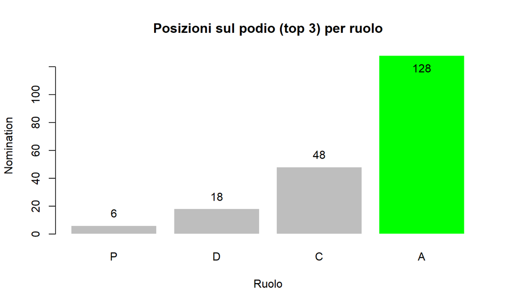

Ora ci concentriamo sugli effettivi vincitori del premio

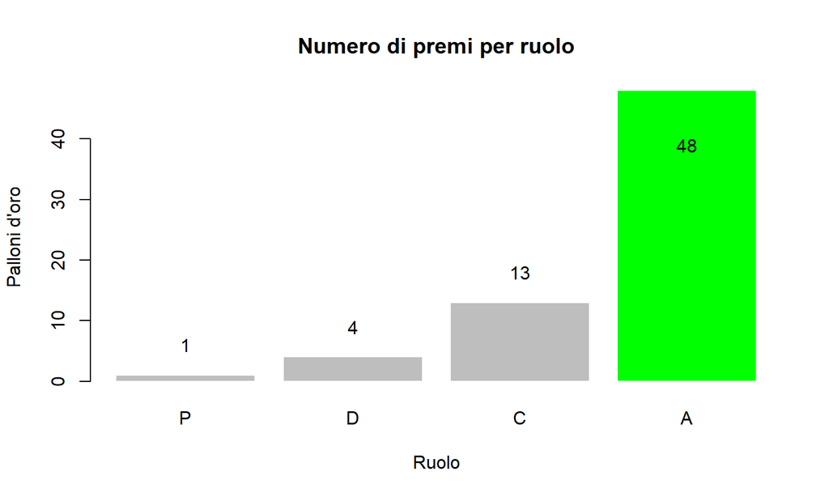

Risulta evidente quindi, anche come previsto, che il ruolo di attaccante sia quello prediletto per vincere un Pallone d’Oro

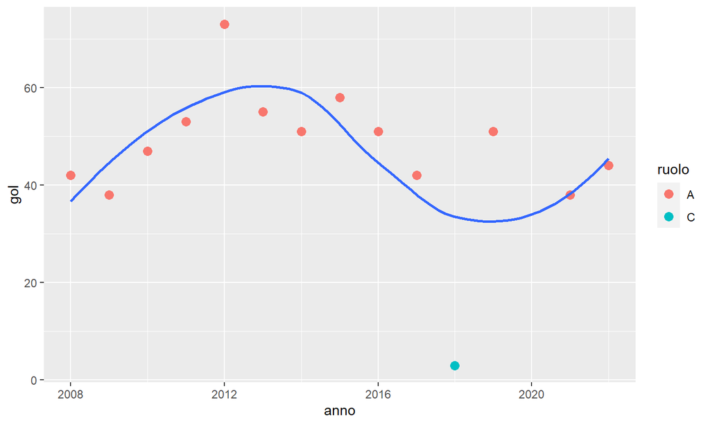

Qui possiamo vedere il trend di Gol fatti negli ultimi 15 anni dai vincitori (l’unico che si discosta dal trend è il solo giocatore di ruolo centrocampista)

## Quali campionati hanno avuto più vincitori del premio?

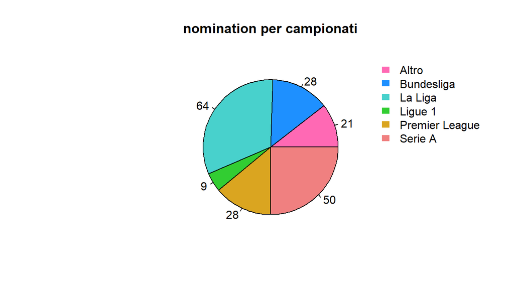

Analizzando le nomination ALL TIME al premio dei TOP 5 campionati, quello spagnolo (La Liga) risulta essere il più coinvolto, seguito dalla Serie A

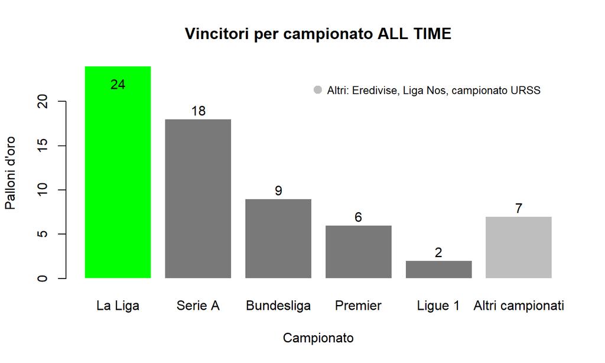

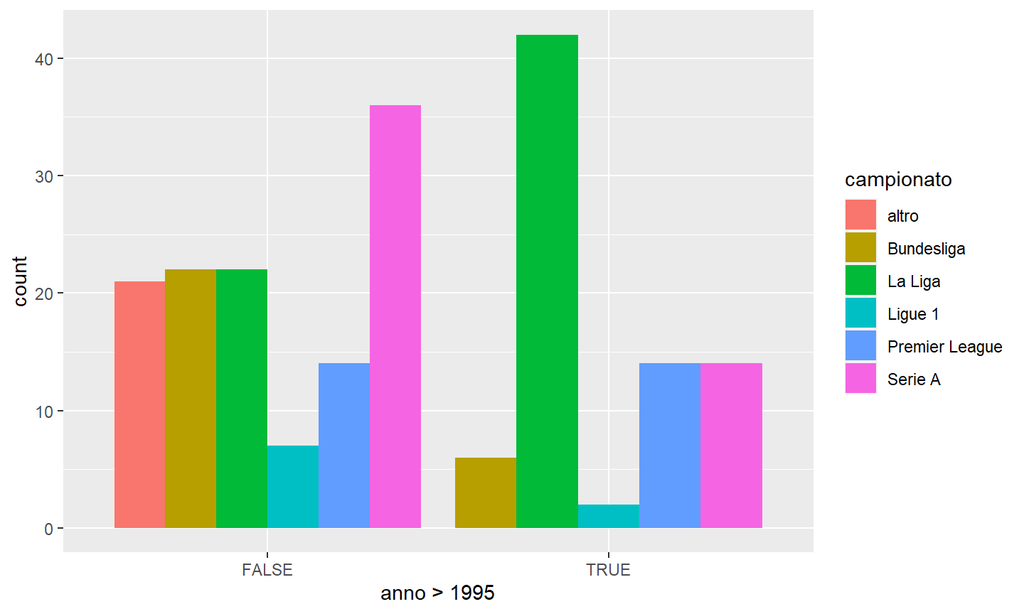

## Che legame ha avuto l’Italia nel tempo con questo premio?

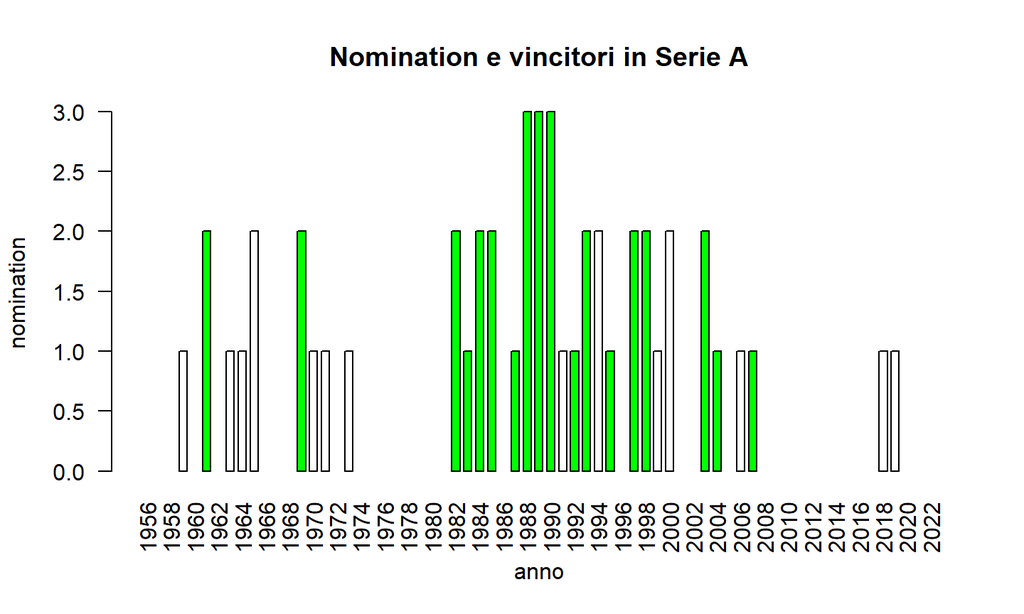

```
##  [1] "Omar Sívori"       "Gianni Rivera"     "Paolo Rossi"
##  [4] "Michel Platini"    "Michel Platini"    "Michel Platini"
##  [7] "Ruud Gullit"       "Marco van Basten"  "Marco van Basten"
## [10] "Lothar Matthäus"   "Marco van Basten"  "Roberto Baggio"
## [13] "George Weah"       "Ronaldo"           "Zinedine Zidane"
## [16] "Pavel Nedvěd"      "Andriy Shevchenko" "Kaká"
```

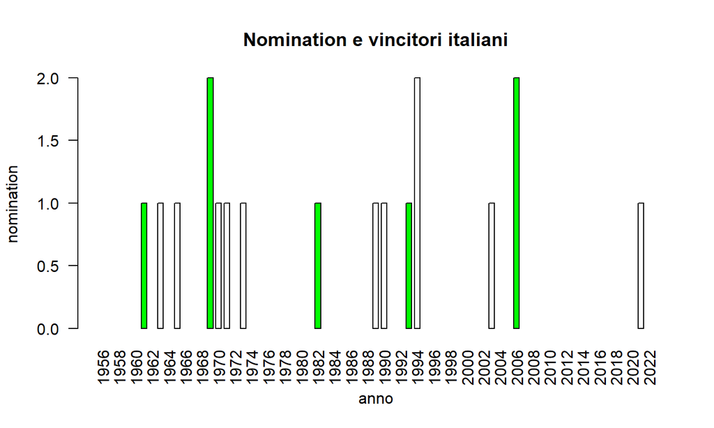

```
## [1] "Omar Sívori"     "Gianni Rivera"   "Paolo Rossi"     "Roberto Baggio"
## [5] "Fabio Cannavaro"
```

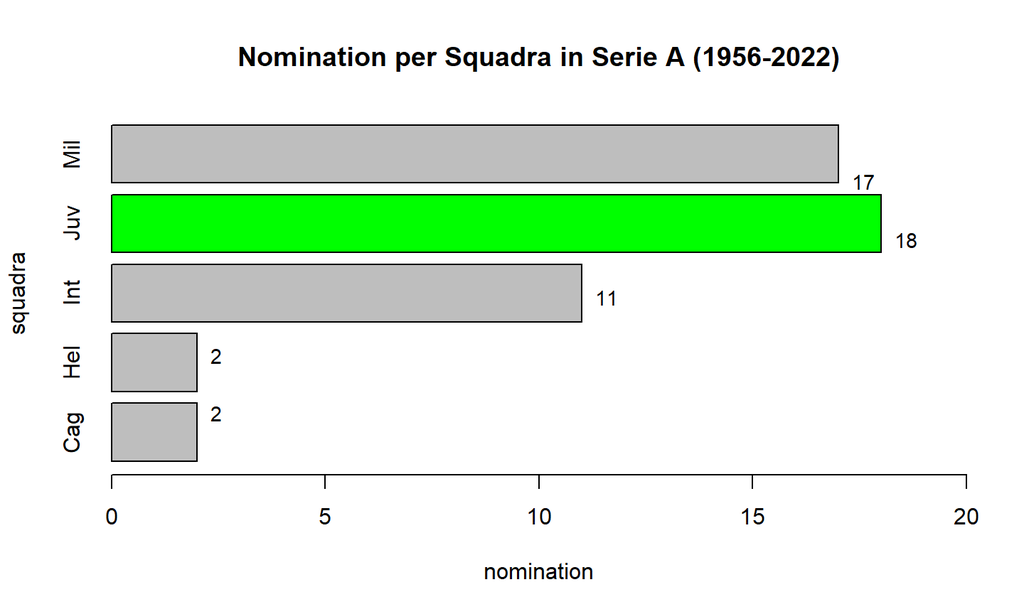

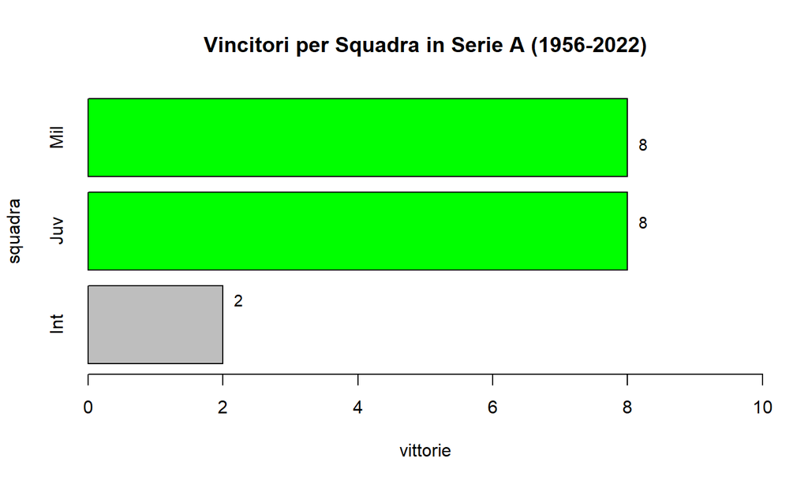

## Si può prevedere il prossimo Pallone d’oro?

Un dato non indifferente da tenere d’occhio è l’evento dei Mondiali che si sono svolti quest’anno

Analizziamo quindi che correlazione c’è stata negli anni tra vincitore del pallone d’oro e nazionale vincitrice del mondiale

ANALISI SUI VINCITORI 2002-2022

```
## [1] "Tra gli ultimi 20 vincitori del premio, in 12 hanno vinto la Champions League nello stesso anno -->  60 %"
```

```
## [1] "negli ultimi 5 Mondiali disputati, invece, solo in 2 su 5 hanno vinto anche il Pallone d'Oro -->  40 %"
```

```
## [1] "Se lo dovesse vincere un argentino però quest'anno, la percentuale salirebbe al  50 %"
```

```
## [1] "Inoltre è interessante come il  65 % abbia vinto almeno 2 titoli di squadra nella stessa stagione"
```

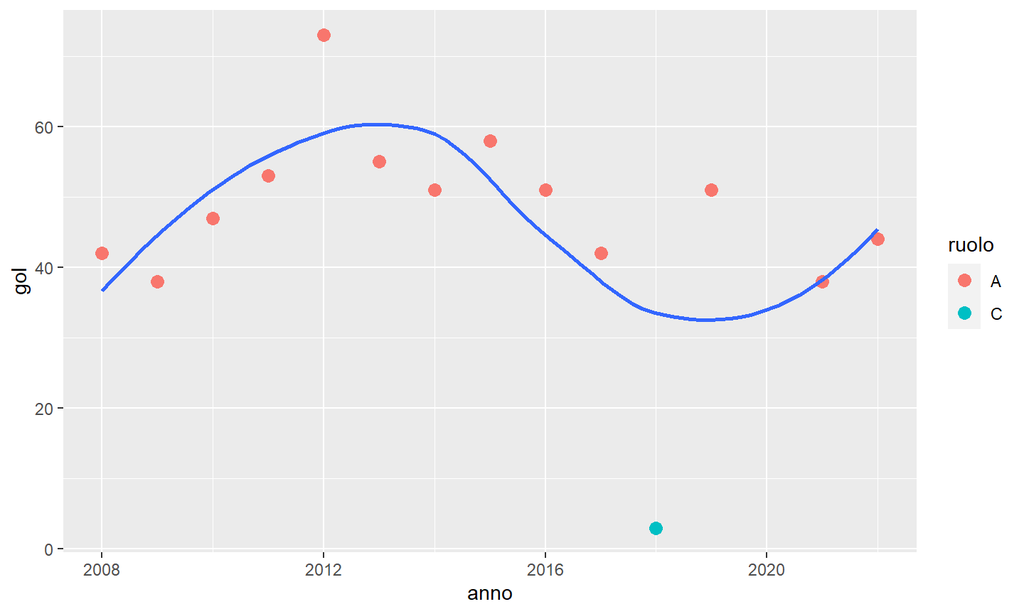

```
## [1] "Mediana dei gol --> 49"
```

```
## [1] "Mediana degli assist --> 15"
```

```
## [1] "Mediana dei gol+assist --> 62.5"
```

## In conclusione…

Ecco una lista dei possibili candidati che ho stilato in base a tutti i dati raccolti

```
## # A tibble: 11 × 7
##    nome               ruolo   gol assist campionato mondiale champions
##    <chr>              <chr> <dbl>  <dbl> <lgl>      <lgl>    <lgl>
##  1 Erling Haaland     A        56      9 TRUE       FALSE    TRUE
##  2 Kylian Mbappe      A        55     14 TRUE       FALSE    FALSE
##  3 Lionel Messi       A        39     25 TRUE       TRUE     FALSE
##  4 Kevin De Bruyne    C        10     32 TRUE       FALSE    TRUE
##  5 Lautaro Martinez   A        29     12 FALSE      TRUE     FALSE
##  6 Robert Lewandowski A        36     11 TRUE       FALSE    FALSE
##  7 Ilkay Gundogan     C        13      7 TRUE       FALSE    TRUE
##  8 Vinicius Junior    A        25     26 FALSE      FALSE    FALSE
##  9 Marcus Rashford    A        34     12 FALSE      FALSE    FALSE
## 10 Rodri              C         4      7 TRUE       FALSE    TRUE
## 11 Victor Osimhen     A        33      5 TRUE       FALSE    FALSE
```